```python
from IPython.display import HTML

HTML('''
<script src='//code.jquery.com/jquery-3.3.1.min.js'></script>
<script>
code_show=true;
function code_toggle() {
if (code_show){
$('div.input').hide();
$('div .jp-CodeCell .jp-Cell-inputWrapper').hide();
} else {
$('div.input').show();
$('div .jp-CodeCell .jp-Cell-inputWrapper').show();
}
code_show = !code_show
}
$( document ).ready(code_toggle);
</script>
<form action="javascript:code_toggle()"><input type="submit" value="Code on/off"></form>''')
```

# SCHOOL SAFETY STUDY OF THE NEW YORK CITY IN THE YEAR OF 2014

## ABSTRACT

School safety is important. We are expecting a safer study environment for the students. However, violence around schools happened frequently in the New York City. The introducing study is an exploratory analysis to evaluate the safety level for all public schools in the New York City, where the results will be helpful for the police department to make decisions.

## INTRODUCTION

The objective of this study is to do a clustering on the public school safety in New York City in order to help the police department to efficiently allocate the resources to against crimes and violence around schools. The introducing analysis was done based on the data from the Education section on the website of NYC Open Data. Three questions will be answered in the following analysis.

#### 1. Are the number of major crimes significantly different in different boroughs? How do major crimes around schools distributed in NYC?

This question will be helpful to have an overview of the location of the major crimes. Number of major crimes might be different in different boroughs.

#### 2. Is there a relationship between math academic performance and number of crimes?

A safer study environment might lead to a better academic performance since students will be willing to go to school and have less concerns if there is less crimes around schools. Here choose the MATH performance as an example.

#### 3. Perform unsupervised learning clustering on the school safety.

A clustering on the school safety level will be helpful for the police department to allocate their resources.

## METHODS

#### PART I. Data Clearning

Demographic Datasets, Safety Reports and Math Exam Performance Reports were generated each year. Here I choose the reports in year of 2014 to do the following analysis. The required libraries are `numpy` and `pandas`. The interested variables and the detailed information are shown below:

1. `DBN`: District Borough Number (New York City Department of Education school identifier)
2. `School Name`: Name of school
3. `Total Enrollment`: The total student enrollment for the district and school year being reported
4. `% Female`: The total percentage of female students enrolled in the district and school year being reported
5. `% Male`: The total percentage of male students enrolled in the district and school year being reported
6. `% Asian`: The total percentage of Asian students enrolled in the district and school year being reported
7. `% Black`: The total percentage of Black students enrolled in the district and school year being reported
8. `% Hispanic`: The total percentage of Hispanic students enrolled in the district and school year being reported
9. `% White`: The total percentage of White students enrolled in the district and school year being reported
10. `% Students with Disabilities`: The total percentage of students with disabilities enrolled in the district and school year being reported
11. `% Poverty`: The total percentage of students qualifying for free or reduced price lunch or are eligible for Human Resources Administration benefits enrolled in the district and school year being reported
12. `% Level 1`: Percentage of students who scored in Level 1 range
13. `% Level 2`: Percentage of students who scored in Level 2 range
14. `% Level 3`: Percentage of students who scored in Level 3 range
15. `% Level 4`: Percentage of students who scored in Level 4 range
16. `% Level 3+4`: Percentage of students who scored in Level 3 and 4 range
17. `Major N`: Number of major crimes
18. `Oth N`: Number of other crimes
19. `NoCrim N`: Number of non-criminal crimes
20. `Prop N`: Number of property crimes
21. `Vio N`: Number of violent crimes
22. `Borough Name`: NYC Boro the location is situated in
23. `Latitude`: Latitude of the location
24. `Longitude`: Longitude of the location

After cleaning, the final dataset contains 1078 records and 24 features.

```python
import warnings
warnings.filterwarnings('ignore')
import numpy as np
import pandas as pd
```

```python
# PATH TO FILE
path_nyc = '/Users/hewanyi/Desktop/WCM/Data Science I/Final Project/DATASET/'
path_nyc_school = '/Users/hewanyi/Desktop/WCM/Data Science I/Final Project/DATASET/High School/'

# DEMOGRAPHIC INFORMATION
nyc_school_demo_1318 = pd.read_csv(path_nyc_school + '2013-2018 Demographic Snapshot School.csv')
nyc_school_demo_2014 = nyc_school_demo_1318[nyc_school_demo_1318['Year'] == '2014-15']

# SAFETY REPORTS
nyc_school_safety_1016 = pd.read_csv(path_nyc_school + '2010-2016 School Safety Report.csv')
nyc_school_safety_2014 = nyc_school_safety_1016[nyc_school_safety_1016['School Year'] == '2014-15']

# MATH EXAM REPORTS
nyc_school_math_1315 = pd.read_csv(path_nyc_school + '2013-2015 New York State Mathematics Exam by School.csv')
nyc_school_math_1315 = nyc_school_math_1315[nyc_school_math_1315.Grade == 'All Grades']
nyc_school_math_2014 = nyc_school_math_1315[nyc_school_math_1315['Year'] == 2014]

# MERGE DATASETS
merge_school_safe = pd.merge(nyc_school_demo_2014, nyc_school_safety_2014, on = 'DBN', how = 'left')
merge_school_MS = pd.merge(nyc_school_math_2014, merge_school_safe, on = 'DBN')

# NEED ALL STUDENTS
merge_school_MS = merge_school_MS[merge_school_MS['Category'] == 'All Students']
```

```python
# SELECT THE INTERESTED VARIABLES
school_MS = merge_school_MS[['DBN',                           # SCHOOL IDENTIFIER
                             'School Name_x',                 # SCHOOL NAME
                             'Total Enrollment',              # TOTAL NUMBER OF ENROLLED STUDENTS
                             '% Female',                      # PERCENTAGE OF FEMALE STUDENTS
                             '% Male',                        # PERCENTAGE OF MALE STUDENTS
                             '% Asian',                       # PERCENTAGE OF ASIAN STUDENTS
                             '% Black',                       # PERCENTAGE OF BLACK STUDENTS
                             '% Hispanic',                    # PERCENTAGE OF HISPANIC STUDENTS
                             '% White',                       # PERCENTAGE OF WHITE STUDENTS
                             '% Students with Disabilities',  # PERCENTAGE OF DISABLED STUDENTS
                             '% Poverty',                     # PERCENTAGE OF STUDENT QUALIFIED FOR BENEFIT
                             '% Level 1',                     # PERCENTAGE OF STUDENT IN GRADE 1
                             '% Level 2',                     # PERCENTAGE OF STUDENT IN GRADE 2
                             '% Level 3',                     # PERCENTAGE OF STUDENT IN GRADE 3
                             '% Level 4',                     # PERCENTAGE OF STUDENT IN GRADE 4
                             '% Level 3+4',                   # PERCENTAGE OF STUDENT IN GRADE 3 and 4
                             'Major N',                       # NUMBER OF MAJOR CRIMES
                             'Oth N',                         # NUMBER OF OTHER CRIMES
                             'NoCrim N',                      # NUMBER OF NON-CRIMINAL VIOLENCE
                             'Prop N',                        # NUMBER OF PROPERTY CRIMES
                             'Vio N',                         # NUMBER OF VIOLENCE CRIMES
                             'Borough Name',                  # BOROUGH
                             'Latitude',                      # LATITUDE
                             'Longitude']]                    # LONGITUDE

# DROP DUPLICATE RECORDS
school_MS = school_MS.drop_duplicates(subset = None, keep = 'first', inplace = False)

# REVALUE FOR MERGING
school_MS = school_MS.rename(columns = {"Borough Name": "Borough", 'School Name_x': 'School Name'})
school_MS = school_MS.replace(to_replace = 'MANHATTAN', value = 'Manhattan')
school_MS = school_MS.replace(to_replace = 'BRONX    ', value = 'Bronx')
school_MS = school_MS.replace(to_replace = 'BROOKLYN ', value = 'Brooklyn')
school_MS = school_MS.replace(to_replace = 'QUEENS   ', value = 'Queens')
school_MS = school_MS.replace(to_replace = 'STATEN IS', value = 'Staten Island')

# FINAL DATASET FOR FURTHER ANALYSIS CONTAINS 1078 RECORDS
# len(school_MS) = 1078
```

#### PART II. Mapping

Observations will be plotted on the NYC map for the purpose of feature visualization. Libraries include `shapely.geometry`, `geopandas`, `matplotlib.pyplot`, `matplotlib.colors` and `matplotlib.cm`. The NYC map was download from the website of NYC Open Data as a shape file.

```python
# LIBRARIES FOR maps
from shapely.geometry import Point, Polygon, LineString
from geopandas import GeoDataFrame, gpd

# LIBRARIES FOR plots
import matplotlib.pyplot as plt
import matplotlib.colors as colors
import matplotlib.cm as cmx

# NYC MAP
nyc_shape = path_nyc_school + 'Borough Boundaries/geo_export_e90597ea-6715-4c34-affe-f23738a4b8b6.shp'
nyc_map = gpd.read_file(nyc_shape)

# RENAME COLUMN
nyc_map = nyc_map.rename(columns = {"boro_name": "Borough"})
```

#### PART III. Tests

1. Kruskal-Wallis test will be performed on the number of major crimes in different boroughs.
2. Pearson test will be performed to see the correlation between number of major crimes and academic performance.

The library is `scipy.stats`.

```python
# LIBRARIY FOR pearson test
from scipy import stats
from scipy.stats import pearsonr

# LIBRARIY FOR Kruskal-Wallss test
from scipy.stats import kruskal
```

#### PART IV. UNSUPERVISED LEARNING

In this part, I'm going to perform the Hierarchical Agglomerative Clustering on the introduced dataset with a dendrogram for the final clustering visualization. Libraries include `sklearn.preprocessing` and `sklearn.cluster`.

```python
# LIBRARY FOR standardization
from sklearn.preprocessing import StandardScaler

# LIBRARY FOR hierarchical clustering algorithm
import scipy.cluster.hierarchy as shc
from sklearn.cluster import AgglomerativeClustering
```

## RESULT

### QUESTION 1. Are the number of major crimes different in different borough? How do major crimes around schools distributed in NYC?

```python
# DROP ALL MISSING VALUES IN MAJOR CRIMES
school_MS = school_MS.dropna(subset = ['Major N', 'Total Enrollment', '% Female','% Students with Disabilities'])
```

#### 1. Hypothesis testing - Kruskal-Wallis

In order to identifying the difference of Number of Major Crimes in different boroughs, we need to perform a hypothesis test on number of major crimes. Since there are totally 5 boroughs and the standard deviations should be assumed unequal, a **kruskal-wallis** test is appropriate. The test results are shown below:

```python
man = school_MS[school_MS['Borough'] == 'Manhattan']
qns = school_MS[school_MS['Borough'] == 'Queens']
brx = school_MS[school_MS['Borough'] == 'Bronx']
bkl = school_MS[school_MS['Borough'] == 'Brooklyn']
stn = school_MS[school_MS['Borough'] == 'Staten Island']
stat, pval = kruskal(man['Major N'], qns['Major N'], brx['Major N'], bkl['Major N'], stn['Major N'])
print('The test statistics is', stat.round(2), 'and the p-value is', pval.round(4))
```

```
The test statistics is 12.28 and the p-value is 0.0154
```

##### Conclusion for Kruskal-Wallis Test

Since p-value < 0.05. Reject H0 at a 0.05 significant level. There is enough evidence to state that there exists a significant difference on number of major crimes among different boroughs at a 0.05 level.

#### 2. Distribution of Crimes in NYC

Add 'Total Enrollment', 'Percentage of Female student' and 'Percentage of Students with Disabilities' as one more dimension to include more information in one plot. The reasons for choosing the above three features are:

(1) More students (people) may "lead to" more crimes.  
(2) More female students may "attract" more crimes.  
(3) More disabled student may "attract" more crimes.

```python
# SET THE MAP AS BACKGROUND
crs = {'init': 'epsg: 4326'}
geometry = [Point(xy) for xy in zip(school_MS['Longitude'], school_MS['Latitude'])]
geo_df = gpd.GeoDataFrame(school_MS, geometry = geometry)
```

##### (1) Location of Major Crimes with information of Total Enrollment

The number of total enrollment is the reported enrolled students for 2014, which is not the total number of student. However, the number of enrolled students are similar every year for most of the schools. Thus, the number of enrollment for one year is a magnitude that is representitive of total number of student in the school. Same for `% Female` and `% Student Disabilities`.

The point size represents the number of major crimes. A larger point corresponds to a greater number of crimes. Same for `% Female` and `% Student Disabilities`.

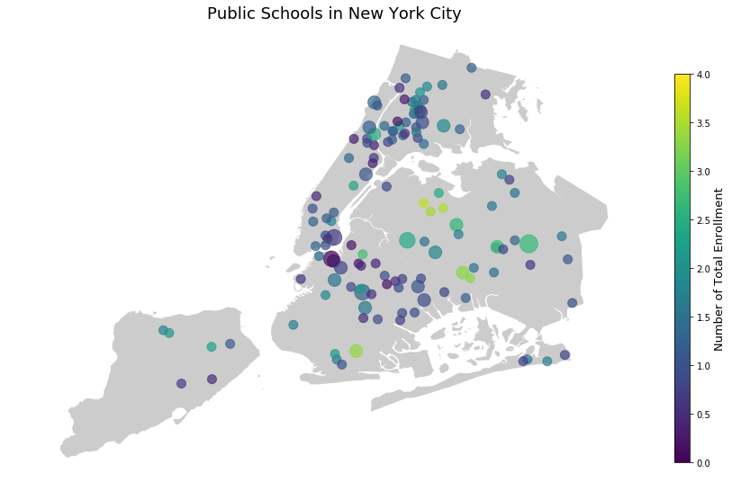

```python
fig, ax = plt.subplots(figsize = (12,12))                      # SET THE SIZE OF FIGURE
fig = ax.get_figure()
cax = fig.add_axes([0.95, 0.23, 0.02, 0.5])                    # POSITION OF COLORSCALE
ax.set_title('Public Schools in New York City', fontsize = 18) # ADD TITLE

nyc_map.plot(ax = ax, alpha = 0.4, color = 'grey')             # SET BACKGROUND COLOR OF MAP
geo_df.plot(ax = ax, marker = 'o',                             # POINT SHAPE
            markersize = geo_df['Major N']*100,                # POINT SIZE RELATED TO NUMBER OF MAJOR CRIMES
            c = geo_df['Total Enrollment'],                    # POINT COLOR DEPTH RELATED TO NUMBER OF TOTAL ENROLLMENT
            alpha = 0.7,                                       # TRANSPARENCY
            legend = True)                                     # WITH LEGEND

sm = plt.cm.ScalarMappable()
sm._A = geo_df['Major N']
cbar = fig.colorbar(sm, cax = cax)                             # ADD COLORSCALE
cbar.set_label('Number of Total Enrollment', fontsize = 13)    # ADD TITLE TO COLORSCALE

ax.axis('off')                                                 # HIDE THE AXIS
plt.show()
```

###### Comment

```python
school_ME = school_MS[['Major N', 'Total Enrollment']].dropna()                # DROP MISSING VALUES
result = stats.pearsonr(school_ME['Major N'], school_ME['Total Enrollment'])   # PEARSON TEST
if result[1] >= 0.0001:
    print('The pearson correlation coefficient between number of major crimes and total student enrollment is',
          result[0].round(4), 'and the P-value is', result[1].round(4))
else: print('The pearson correlation coefficient between number of major crimes and total student enrollment is',
          result[0].round(4), 'and the P-value is less than 0.0001')
```

```
The pearson correlation coefficient between number of major crimes and total student enrollment is 0.1163 and the P-value is 0.0022
```

##### (2) Location of Major Crimes with information of Percentage of Female Student

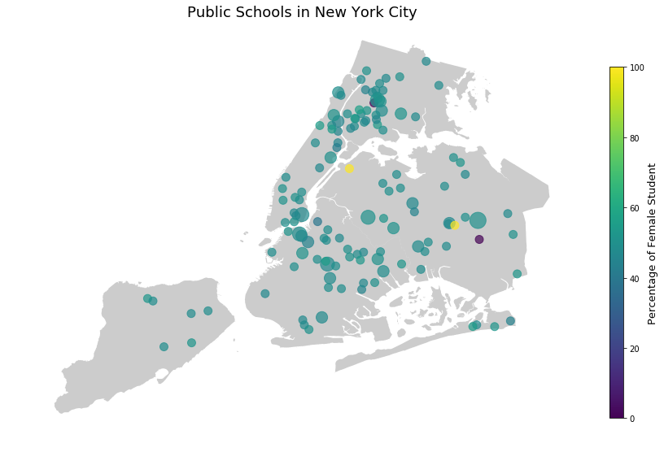

```python
fig, ax = plt.subplots(figsize = (12,12))                     # SET THE SIZE OF FIGURE
fig = ax.get_figure()
cax = fig.add_axes([0.95, 0.23, 0.02, 0.5])                   # POSITION OF COLORSCALE
ax.set_title('Public Schools in New York City', fontsize = 18)# ADD TITLE

nyc_map.plot(ax = ax, alpha = 0.4, color = 'grey')            # SET BACKGROUND COLOR OF MAP
geo_df.plot(ax = ax, marker = 'o',                            # POINT SHAPE
            markersize = geo_df['Major N']*100,               # POINT SIZE RELATED TO NUMBER OF MAJOR CRIMES
            c = geo_df['% Female'],                           # POINT COLOR DEPTH RELATED TO NUMBER OF TOTAL ENROLLMENT
            alpha = 0.7,                                      # TRANSPARENCY
            legend = True)                                    # WITH LEGEND

sm = plt.cm.ScalarMappable()
sm._A = geo_df['% Female']
cbar = fig.colorbar(sm, cax = cax)                            # ADD COLORSCALE
cbar.set_label('Percentage of Female Student', fontsize = 13) # ADD TITLE TO COLORSCALE

ax.axis('off')                                                # HIDE THE AXIS
plt.show()
```

##### (3) Location of Major Crimes with information of Percentage of Disabled Student

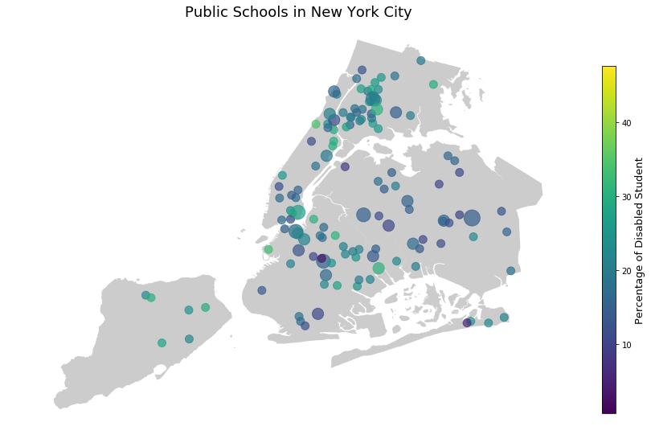

```python
fig, ax = plt.subplots(figsize = (12,12))                     # SET THE SIZE OF FIGURE
fig = ax.get_figure()
cax = fig.add_axes([0.95, 0.23, 0.02, 0.5])                   # POSITION OF COLORSCALE
ax.set_title('Public Schools in New York City',fontsize = 18) # ADD TITLE

nyc_map.plot(ax = ax, alpha = 0.4, color = 'grey')            # SET BACKGROUND COLOR OF MAP
geo_df.plot(ax = ax, marker = 'o',                            # POINT SHAPE
            markersize = geo_df['Major N']*100,               # POINT SIZE RELATED TO NUMBER OF MAJOR CRIMES
            c = geo_df['% Students with Disabilities'],       # POINT COLOR DEPTH RELATED TO PERCENT OF DISABLED STUDENTS
            alpha = 0.7,                                      # TRANSPARENCY
            legend = True)                                    # WITH LEGEND

sm = plt.cm.ScalarMappable()
sm._A = geo_df['% Students with Disabilities']
cbar = fig.colorbar(sm, cax = cax)                              # ADD COLORSCALE
cbar.set_label('Percentage of Disabled Student', fontsize = 13) # ADD TITLE TO COLORSCALE

ax.axis('off')                                                  # HIDE THE AXIS
plt.show()
```

###### Comment

The above plot does not show a significant relationship between the number of major crimes and percentage of disabled students.

### QUESTION 2. Is there a relationship between math academic performance and number of major crimes?

For this question, since number of crimes and math academic performance are all continuous, a **Pearson** test is appropriate.

###### Notes

(1) The percentage of Grade 1, 2, 3 and 4 are sum to ONE.  
(2) Both Grade 3 and Grade 4 mean a good performance on the math study, thus `% Level 3+4` is the main variable to be analyzed.

```python
# DROP MISSING VALUES FOR THE INTERESTED VARIABLES and RENAME THE COLUMNS
school_MATH = school_MS[['Borough', 'Major N', '% Level 3+4', 'NoCrim N', 'Prop N', 'Vio N', 'Oth N',
                         '% Level 1', '% Level 2', '% Level 3', '% Level 4']]
school_MATH = school_MATH.rename(columns = {"Borough Name": "Borough",
                                           '% Level 3+4': '% student in Grade 3+4',
                                           '% Level 1': '% student in Grade 1', '% Level 2': '% student in Grade 2',
                                           '% Level 3': '% student in Grade 3', '% Level 4': '% student in Grade 4',
                                           'Major N': 'Major Crimes', 'NoCrim N': 'Non-Criminal Crimes',
                                           'Prop N': 'Property Crimes', 'Vio N': 'Violence Crimes',
                                           'Oth N': 'Other Crimes'})
school_MATH = school_MATH.dropna()
```

#### 1. Overview of the mean values for each columns

```python
school_MATH.groupby('Borough').mean().round(2)  # ROUND TO 2 DECIMAL PLACES
```

| Borough | Major Crimes | % student in Grade 3+4 | Non-Criminal Crimes | Property Crimes | Violence Crimes | Other Crimes | % student in Grade 1 | % student in Grade 2 | % student in Grade 3 | % student in Grade 4 |
| --- | --- | --- | --- | --- | --- | --- | --- | --- | --- | --- |
| Bronx | 0.30 | 23.51 | 1.65 | 0.77 | 0.46 | 1.13 | 41.85 | 34.64 | 16.83 | 6.68 |
| Brooklyn | 0.22 | 37.32 | 1.11 | 0.62 | 0.40 | 0.87 | 31.54 | 31.15 | 21.70 | 15.62 |
| Manhattan | 0.34 | 39.56 | 1.48 | 0.85 | 0.47 | 1.03 | 31.33 | 29.11 | 20.73 | 18.84 |
| Queens | 0.19 | 46.84 | 0.71 | 0.47 | 0.17 | 0.47 | 22.73 | 30.44 | 25.58 | 21.26 |
| Staten Island | 0.12 | 42.40 | 1.29 | 0.60 | 0.40 | 1.00 | 25.29 | 32.33 | 26.19 | 16.21 |

#### 2. Correlation test for "Number of Major Crimes" and "Percentage of Students in Grade 3 and 4"

```python
result = stats.pearsonr(school_MATH['Major Crimes'], school_MATH['% student in Grade 3+4'])  # PEARSON TEST
if result[1] >= 0.0001:
    print('The pearson correlation coefficient between number of major crimes and percent of student in Grade 3 and 4 is',
          result[0].round(4), 'and the P-value is', result[1].round(4))
else: print('The pearson correlation coefficient between number of major crimes and percent of student in Grade 3 and 4 is',
          result[0].round(4), 'and the P-value is less than 0.0001')
```

```
The pearson correlation coefficient between number of major crimes and percent of student in Grade 3 and 4 is -0.1733 and the P-value is less than 0.0001
```

#### 3. Location of Major Crimes related to Math Performance

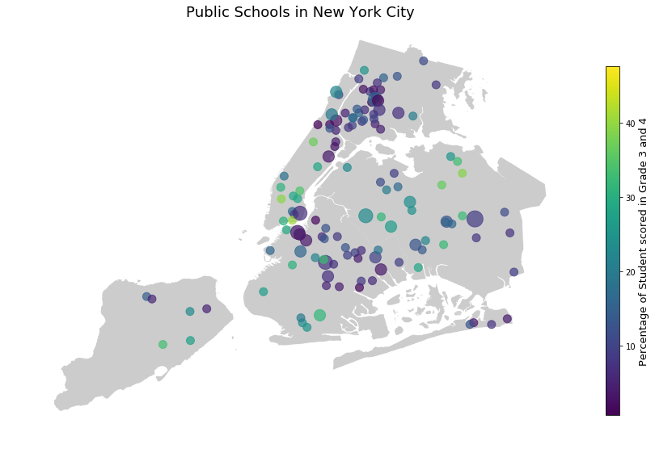

```python
fig, ax = plt.subplots(figsize = (12,12))                     # SET THE SIZE OF FIGURE
fig = ax.get_figure()
cax = fig.add_axes([0.95, 0.23, 0.02, 0.5])                   # POSITION OF COLORSCALE
ax.set_title('Public Schools in New York City',fontsize = 18) # ADD TITLE

nyc_map.plot(ax = ax, alpha = 0.4, color = 'grey')            # SET BACKGROUND COLOR OF MAP
geo_df.plot(ax = ax, marker = 'o',                            # POINT SHAPE
            markersize = geo_df['Major N']*100,               # POINT SIZE RELATED TO NUMBER OF MAJOR CRIMES
            c = geo_df['% Level 3+4'],                        # POINT COLOR DEPTH RELATED TO PERCENT OF STUDENT SCORED IN GRADE 3 AND 4
            alpha = 0.7,                                      # TRANSPARENCY
            legend = True)                                    # WITH LEGEND

sm = plt.cm.ScalarMappable()
sm._A = geo_df['% Students with Disabilities']
cbar = fig.colorbar(sm, cax = cax)                                             # ADD COLORSCALE
cbar.set_label('Percentage of Student scored in Grade 3 and 4', fontsize = 13) # ADD TITLE TO COLORSCALE

ax.axis('off')                                                                 # HIDE THE AXIS
plt.show()
```

### QUESTION 3. Perform an unsupervised clustering on the school safety

```python
# Here delete the math performance since those features are not related to school safety
cluster_tbl = school_MS[['DBN','School Name','Borough','Total Enrollment','% Female','% Asian','% Black',
                         '% Hispanic','% White','% Poverty','% Students with Disabilities','Major N','Oth N',
                         'NoCrim N', 'Prop N']] # DBN and School Name are saved for final table
cluster_tbl = cluster_tbl.dropna()

# Data for clustering
cluster_safety = cluster_tbl[['Borough','% Female','% Asian','% Black','% Hispanic','% White',
                              'Total Enrollment', '% Students with Disabilities', '% Poverty',
                              'Major N', 'Oth N', 'NoCrim N', 'Prop N']]

# Revalue the categorical data for clustering
cluster_safety = cluster_safety.replace(to_replace = 'Manhattan', value = 1)
cluster_safety = cluster_safety.replace(to_replace = 'Queens', value = 2)
cluster_safety = cluster_safety.replace(to_replace = 'Bronx', value = 3)
cluster_safety = cluster_safety.replace(to_replace = 'Brooklyn', value = 4)
cluster_safety = cluster_safety.replace(to_replace = 'Staten Island', value = 5)
# len(cluster_safety) = 693
```

In this part, an unsupervised clustering will be performed to classify the schools based on their safety levels. Academic performance features are excluded since they do not affect the safety. The included features are:

**Demographic Information**

`Borough`, `Total Enrollment`,`% Female`, `% Asian`,`% Black`,`% Hispanic`,`% White`,`% Students with Disabilities`, `% Poverty`

**Safety Report**

`Major N`, `Oth N`, `NoCrim N`, `Prop N`

### Dengrogram

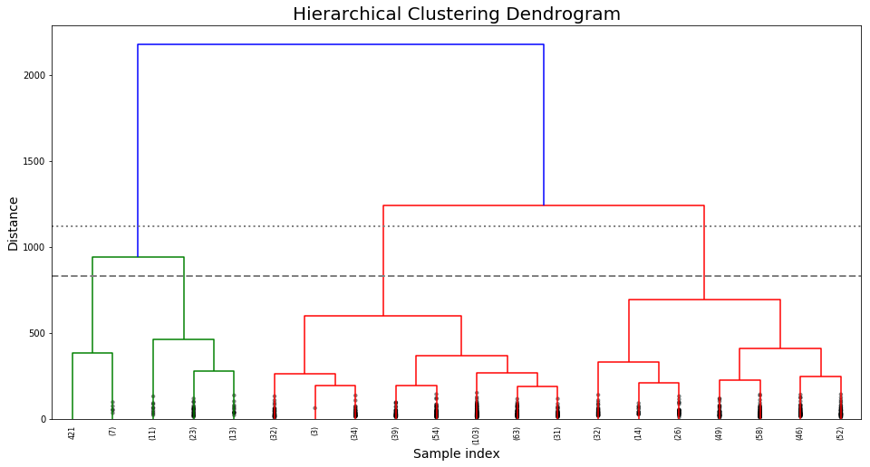

```python
# FULL DENDROGRAM
plt.figure(figsize = (16, 8))
plt.title('Hierarchical Clustering Dendrogram', fontsize = 20)  # add title
plt.xlabel('Sample index', fontsize = 14)                       # add label on x-axis and set font size
plt.ylabel('Distance', fontsize = 14)                           # add label on y-axis and set font size
shc.dendrogram(
    shc.linkage(cluster_safety, method ='complete'),            # use complete linkage
    truncate_mode = 'lastp',                                    # show only the last p merged clusters
    leaf_rotation = 90.,                                        # rotates the x axis labels
    leaf_font_size = 8.,                                        # font size for the x axis labels
    p = 20,                                                     # show only the last p merged clusters
    orientation = 'top',
    distance_sort = 'descending',
    show_contracted = True,
    show_leaf_counts = True
)
plt.axhline(y = 1120, c ='grey', lw = 2, linestyle = 'dotted')  # horizontal line for 3 clusters
plt.axhline(y = 830, c ='grey', lw = 2, linestyle = 'dashed')   # horizontal line for 4 clusters
plt.show()
```

According to the dengrogram, I'm going to perform Hierarchical Agglomerative Clustering with 3 clusters and 4 clusters for different attempts.

#### Clustering outcome with 3 safety levels (Top 10 records)

```python
# SET 3 CLUSTERS
cluster_N3 = AgglomerativeClustering(n_clusters = 3,          # 4 CLUSTERS
                                     affinity = 'euclidean',  # CALCULATED BY EUCLIDEAN DISTANCE
                                     linkage = 'complete')    # COMPLETE LINKAGE
RE_N3 = cluster_N3.fit_predict(cluster_safety)
# len(RE_N3) = 693

HAC_3_dat = pd.concat([pd.DataFrame(cluster_tbl).reset_index(drop = True),
                       pd.DataFrame(RE_N4).reset_index(drop = True)], axis = 1)           # COMBINE THE DATAFRAMES
HAC_3_dat = HAC_3_dat.rename(columns = {'Major N': 'Major Crimes', 'Oth N': 'Other Crimes',
                                       'NoCrim N': 'Non-Criminal Crimes', 'Prop N': 'Property Crimes',
                                        0: 'Safety Level'})                               # RENAME THE COLUMNS
HAC_3_dat['Safety Level'] = HAC_3_dat['Safety Level'].map({0: '1st', 1: '2nd', 2: '3rd'}) # REVALUE
HAC_3_display_tbl = HAC_3_dat[['DBN', 'School Name', 'Borough', 'Safety Level']]
HAC_3_display_tbl.head(10)
```

[output not shown]

#### Clustering outcome with 4 safety levels (Top 10 records)

```python
# SET 4 CLUSTERS
cluster_N4 = AgglomerativeClustering(n_clusters = 4,          # 4 CLUSTERS
                                     affinity = 'euclidean',  # CALCULATED BY EUCLIDEAN DISTANCE
                                     linkage = 'complete')    # COMPLETE LINKAGE
RE_N4 = cluster_N4.fit_predict(cluster_safety)
# len(RE_N4) = 693

HAC_4_dat = pd.concat([pd.DataFrame(cluster_tbl).reset_index(drop = True),
                       pd.DataFrame(RE_N4).reset_index(drop = True)], axis = 1)
HAC_4_dat = HAC_4_dat.rename(columns = {'Major N': 'Major Crimes', 'Oth N': 'Other Crimes',
                                       'NoCrim N': 'Non-Criminal Crimes', 'Prop N': 'Property Crimes',
                                       0: 'Safety Level'})
HAC_4_dat['Safety Level'] = HAC_4_dat['Safety Level'].map({0: '1st', 1: '2nd', 2: '3rd', 3: '4th'})
HAC_4_display_tbl = HAC_4_dat[['DBN', 'School Name', 'Borough', 'Safety Level']]
HAC_4_display_tbl.head(10)
```

|  | DBN | School Name | Borough | Safety Level |
| --- | --- | --- | --- | --- |
| 0 | 01M015 | P.S. 015 ROBERTO CLEMENTE | Manhattan | 3rd |
| 1 | 01M020 | P.S. 020 ANNA SILVER | Manhattan | 3rd |
| 2 | 01M034 | P.S. 034 FRANKLIN D. ROOSEVELT | Manhattan | 3rd |
| 3 | 01M110 | P.S. 110 FLORENCE NIGHTINGALE | Manhattan | 3rd |
| 4 | 01M140 | P.S. 140 NATHAN STRAUS | Manhattan | 3rd |
| 5 | 01M142 | P.S. 142 AMALIA CASTRO | Manhattan | 3rd |
| 6 | 01M184 | P.S. 184M SHUANG WEN | Manhattan | 3rd |
| 7 | 01M188 | P.S. 188 THE ISLAND SCHOOL | Manhattan | 3rd |
| 8 | 01M450 | EAST SIDE COMMUNITY SCHOOL | Manhattan | 3rd |
| 9 | 01M539 | NEW EXPLORATIONS INTO SCIENCE, TECHNOLOGY AND ... | Manhattan | 2nd |

## CONCLUSION

1. Identified that the number of major crimes are significantly different among boroughs at a 0.05 significance level, I furtherly found that more crimes occur around the schools with more students enrolled. It is highly probable that the number of major crimes is not related to the percentage of female student and percentage of students with disabilities.
2. There exists a significant relationship between students' math exam performance and number of major crimes. Generally speaking, a safer study environment is beneficial to students' academic performance.
3. On the selected features, hierarchical agglomerative clustering was performed by 3 clusters and 4 clusters. Here attached the summary table for both clustering outcomes.

#### Summary table for clustering outcome with 3 clusters

```python
HAC_3_count_tbl = HAC_3_display_tbl[['Safety Level','Borough','DBN']]       # SELECT THE VARIABLES TO BE DISPLAYED
count_tbl_N3 = HAC_3_count_tbl.groupby(['Borough','Safety Level']).count()  # GROUP BY AND COUNT
count_tbl_N3.rename(columns = {'DBN': 'Number of School'})
```

[output not shown]

#### Summary table for clustering outcome with 4 clusters

```python
HAC_4_count_tbl = HAC_4_display_tbl[['Safety Level','Borough','DBN']]       # SELECT THE VARIABLES TO BE DISPLAYED
count_tbl_N4 = HAC_4_count_tbl.groupby(['Borough','Safety Level']).count()  # GROUP BY AND COUNT
count_tbl_N4.rename(columns = {'DBN': 'Number of School'})
```

| Borough | Safety Level | Number of School |
| --- | --- | --- |
| Bronx | 1st | 59 |
|  | 2nd | 7 |
|  | 3rd | 58 |
| Brooklyn | 1st | 77 |
|  | 2nd | 13 |
|  | 3rd | 121 |
|  | 4th | 1 |
| Manhattan | 1st | 21 |
|  | 2nd | 3 |
|  | 3rd | 67 |
| Queens | 1st | 89 |
|  | 2nd | 22 |
|  | 3rd | 94 |
|  | 4th | 7 |
| Staten Island | 1st | 31 |
|  | 2nd | 2 |
|  | 3rd | 19 |

## APPENDIX

#### 1. Have a general look at the original data

```python
school_MS.head() # VIEW TOP 5 RECORDS
```

|  | DBN | School Name | Total Enrollment | % Female | % Male | % Asian | % Black | % Hispanic | % White | % Students with Disabilities | ... | % Level 4 | % Level 3+4 | Major N | Oth N | NoCrim N | Prop N | Vio N | Borough | Latitude | Longitude |
| --- | --- | --- | --- | --- | --- | --- | --- | --- | --- | --- | --- | --- | --- | --- | --- | --- | --- | --- | --- | --- | --- |
| 0 | 01M015 | P.S. 015 ROBERTO CLEMENTE | 183 | 45.9 | 54.1 | 4.4 | 35.5 | 58.5 | 1.1 | 35.0 | ... | 3.2 | 9.5 | 0.0 | 1.0 | 1.0 | 1.0 | 0.0 | Manhattan | 40.721807 | -73.979022 |
| 11 | 01M019 | P.S. 019 ASHER LEVY | 270 | 48.9 | 51.1 | 11.1 | 17.4 | 58.5 | 10.0 | 30.4 | ... | 15.4 | 42.3 | NaN | NaN | NaN | NaN | NaN | Manhattan | 40.729636 | -73.983818 |
| 23 | 01M020 | P.S. 020 ANNA SILVER | 633 | 47.6 | 52.4 | 36.5 | 8.4 | 48.8 | 3.9 | 22.7 | ... | 12.9 | 34.3 | 1.0 | 1.0 | 3.0 | 1.0 | 1.0 | Manhattan | 40.721540 | -73.986648 |
| 35 | 01M034 | P.S. 034 FRANKLIN D. ROOSEVELT | 395 | 50.4 | 49.6 | 6.3 | 27.8 | 62.0 | 3.5 | 30.1 | ... | 6.1 | 27.7 | 0.0 | 3.0 | 1.0 | 1.0 | 2.0 | Manhattan | 40.726473 | -73.975181 |
| 47 | 01M063 | THE STAR ACADEMY - P.S.63 | 199 | 49.2 | 50.8 | 7.0 | 20.6 | 62.3 | 10.1 | 34.2 | ... | 11.3 | 32.1 | NaN | NaN | NaN | NaN | NaN | Manhattan | 40.724117 | -73.986381 |

5 rows × 24 columns

#### 2. Check missing values for each columns

```python
miss_val = pd.DataFrame(school_MS.isnull().sum())                        # CHECK THE NUMBER OF MISSING VALUES
miss_val = miss_val.rename(columns = {0: 'Number of Missing Values'})    # RENAME THE COLUMN
miss_val
```

|  | Number of Missing Values |
| --- | --- |
| DBN | 0 |
| School Name | 0 |
| Total Enrollment | 0 |
| % Female | 0 |
| % Male | 0 |
| % Asian | 0 |
| % Black | 0 |
| % Hispanic | 0 |
| % White | 0 |
| % Students with Disabilities | 0 |
| % Poverty | 0 |
| % Level 1 | 0 |
| % Level 2 | 0 |
| % Level 3 | 0 |
| % Level 4 | 0 |
| % Level 3+4 | 0 |
| Major N | 385 |
| Oth N | 385 |
| NoCrim N | 385 |
| Prop N | 385 |
| Vio N | 385 |
| Borough | 7 |
| Latitude | 7 |
| Longitude | 7 |

#### 3. Check number of non-missing values in each columns by borough

```python
school_MS.groupby('Borough').count()
```

| Borough | DBN | School Name | Total Enrollment | % Female | % Male | % Asian | % Black | % Hispanic | % White | % Students with Disabilities | ... | % Level 3 | % Level 4 | % Level 3+4 | Major N | Oth N | NoCrim N | Prop N | Vio N | Latitude | Longitude |
| --- | --- | --- | --- | --- | --- | --- | --- | --- | --- | --- | --- | --- | --- | --- | --- | --- | --- | --- | --- | --- | --- |
| Bronx | 240 | 240 | 240 | 240 | 240 | 240 | 240 | 240 | 240 | 240 | ... | 240 | 240 | 240 | 124 | 124 | 124 | 124 | 124 | 240 | 240 |
| Brooklyn | 337 | 337 | 337 | 337 | 337 | 337 | 337 | 337 | 337 | 337 | ... | 337 | 337 | 337 | 212 | 212 | 212 | 212 | 212 | 337 | 337 |
| Manhattan | 184 | 184 | 184 | 184 | 184 | 184 | 184 | 184 | 184 | 184 | ... | 184 | 184 | 184 | 91 | 91 | 91 | 91 | 91 | 184 | 184 |
| Queens | 254 | 254 | 254 | 254 | 254 | 254 | 254 | 254 | 254 | 254 | ... | 254 | 254 | 254 | 212 | 212 | 212 | 212 | 212 | 254 | 254 |
| Staten Island | 56 | 56 | 56 | 56 | 56 | 56 | 56 | 56 | 56 | 56 | ... | 56 | 56 | 56 | 52 | 52 | 52 | 52 | 52 | 56 | 56 |

5 rows × 23 columns

#### 4. Check means for each columns by borough

```python
school_MS.groupby('Borough').mean().round(2) # SUMMARIZE DATASET ON MEANS BY BOROUGH
```

| Borough | Total Enrollment | % Female | % Male | % Asian | % Black | % Hispanic | % White | % Students with Disabilities | % Poverty | % Level 1 | ... | % Level 3 | % Level 4 | % Level 3+4 | Major N | Oth N | NoCrim N | Prop N | Vio N | Latitude | Longitude |
| --- | --- | --- | --- | --- | --- | --- | --- | --- | --- | --- | --- | --- | --- | --- | --- | --- | --- | --- | --- | --- | --- |
| Bronx | 607.75 | 49.15 | 50.85 | 3.36 | 27.96 | 64.03 | 3.65 | 22.33 | 86.41 | 45.38 | ... | 14.56 | 5.52 | 20.07 | 0.30 | 1.13 | 1.65 | 0.77 | 0.46 | 40.85 | -73.89 |
| Brooklyn | 602.32 | 49.41 | 50.59 | 11.44 | 42.07 | 30.65 | 14.37 | 19.62 | 76.75 | 35.97 | ... | 19.26 | 12.14 | 31.40 | 0.22 | 0.87 | 1.11 | 0.62 | 0.40 | 40.66 | -73.95 |
| Manhattan | 478.16 | 49.04 | 50.96 | 10.69 | 20.91 | 47.08 | 18.66 | 21.50 | 65.05 | 31.66 | ... | 20.96 | 17.35 | 38.30 | 0.34 | 1.03 | 1.48 | 0.85 | 0.47 | 40.79 | -73.96 |
| Queens | 790.10 | 48.98 | 51.02 | 27.39 | 23.05 | 32.93 | 14.16 | 16.45 | 70.26 | 24.75 | ... | 24.39 | 19.46 | 43.84 | 0.19 | 0.47 | 0.71 | 0.47 | 0.17 | 40.71 | -73.82 |
| Staten Island | 752.14 | 48.86 | 51.14 | 7.24 | 12.38 | 29.56 | 49.17 | 24.44 | 58.14 | 26.76 | ... | 25.37 | 15.38 | 40.76 | 0.12 | 1.00 | 1.29 | 0.60 | 0.40 | 40.59 | -74.14 |

5 rows × 21 columns

#### 5. Check medians for each columns by borough

```python
school_MS.groupby('Borough').median().round(2)  # SUMMARIZE DATASET ON MEDIANS BY BOROUGH
```

| Borough | Total Enrollment | % Female | % Male | % Asian | % Black | % Hispanic | % White | % Students with Disabilities | % Poverty | % Level 1 | ... | % Level 3 | % Level 4 | % Level 3+4 | Major N | Oth N | NoCrim N | Prop N | Vio N | Latitude | Longitude |
| --- | --- | --- | --- | --- | --- | --- | --- | --- | --- | --- | --- | --- | --- | --- | --- | --- | --- | --- | --- | --- | --- |
| Bronx | 558.0 | 48.60 | 51.40 | 1.6 | 25.30 | 68.30 | 1.2 | 21.80 | 89.50 | 45.70 | ... | 14.00 | 3.65 | 17.65 | 0.0 | 1.0 | 1.0 | 0.0 | 0.0 | 40.84 | -73.89 |
| Brooklyn | 525.0 | 48.80 | 51.20 | 3.7 | 43.80 | 23.90 | 3.1 | 18.80 | 81.00 | 37.80 | ... | 17.90 | 7.00 | 24.80 | 0.0 | 0.0 | 1.0 | 0.0 | 0.0 | 40.66 | -73.95 |
| Manhattan | 445.0 | 48.90 | 51.10 | 4.6 | 14.35 | 44.05 | 4.4 | 19.75 | 76.45 | 28.25 | ... | 21.30 | 8.85 | 31.95 | 0.0 | 0.0 | 1.0 | 1.0 | 0.0 | 40.79 | -73.96 |
| Queens | 671.0 | 48.65 | 51.35 | 23.4 | 6.40 | 26.90 | 5.4 | 15.80 | 74.05 | 21.55 | ... | 25.55 | 15.90 | 43.00 | 0.0 | 0.0 | 0.0 | 0.0 | 0.0 | 40.72 | -73.82 |
| Staten Island | 733.5 | 48.90 | 51.10 | 5.6 | 5.10 | 24.80 | 54.3 | 23.50 | 58.60 | 21.80 | ... | 28.60 | 15.85 | 44.90 | 0.0 | 0.0 | 1.0 | 0.0 | 0.0 | 40.59 | -74.13 |

5 rows × 21 columns

#### 6. Check the distirbutions of each columns

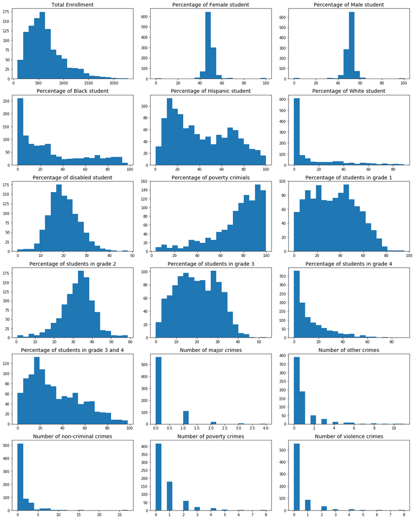

```python
def compare(data, name, fig, rows, cols):               # FUNCTION TO DISPLAY SEVERAL HISTOGRAMS (ONLINE)
    for i in range (0, len(data)):
        plt.figure(figsize = (10,5))                    # SET THE FIGURE SIZE
        plt.figure(fig)
        plt.subplot(rows, cols, i+1)
        plt.hist(data[i], bins = 20)                    # PLOT THE HISTOGRAMS ONE BY ONE WITH NUMBER OF BINS = 20
        plt.title(name[i], fontsize = 14)               # ADD TITLE
    return

plt.figure(figsize = (16,20))
compare([school_MS['Total Enrollment'],
         school_MS['% Female'],
         school_MS['% Male'],
         school_MS['% Black'],
         school_MS['% Hispanic'],
         school_MS['% White'],
         school_MS['% Students with Disabilities'],
         school_MS['% Poverty'],
         school_MS['% Level 1'],
         school_MS['% Level 2'],
         school_MS['% Level 3'],
         school_MS['% Level 4'],
         school_MS['% Level 3+4'],
         school_MS['Major N'],
         school_MS['Oth N'],
         school_MS['NoCrim N'],
         school_MS['Prop N'],
         school_MS['Vio N']],
         ['Total Enrollment', 'Percentage of Female student', 'Percentage of Male student',
          'Percentage of Black student', 'Percentage of Hispanic student', 'Percentage of White student',
          'Percentage of disabled student', 'Percentage of poverty crimials',
          'Percentage of students in grade 1', 'Percentage of students in grade 2',
          'Percentage of students in grade 3', 'Percentage of students in grade 4',
          'Percentage of students in grade 3 and 4',
          'Number of major crimes', 'Number of other crimes', 'Number of non-criminal crimes',
          'Number of poverty crimes','Number of violence crimes'],     # ADD TITLES TO SUBPLOTS
        fig = 1, rows = 6, cols = 3)
plt.tight_layout()                                                     # INCREASE THE SPACE BETWEEN PLOTS
plt.show()
```

#### 7. Check distributions of major crimes in each borough

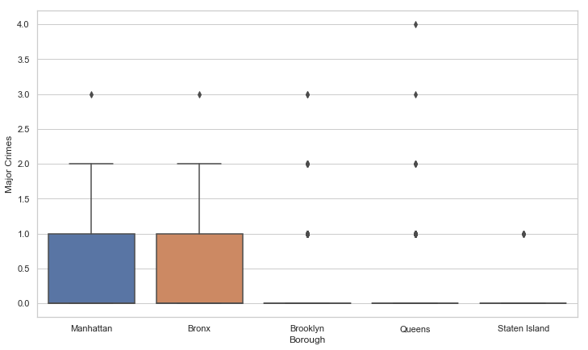

```python
import seaborn as sns
plt.figure(figsize = (12, 7))
sns.set(style = "whitegrid")
ax = sns.boxplot(x = "Borough", y = "Major N", data = school_MS)
ax.set(xlabel = 'Borough', ylabel = 'Major Crimes')
plt.show()
```

#### 8. Check the correlation between features

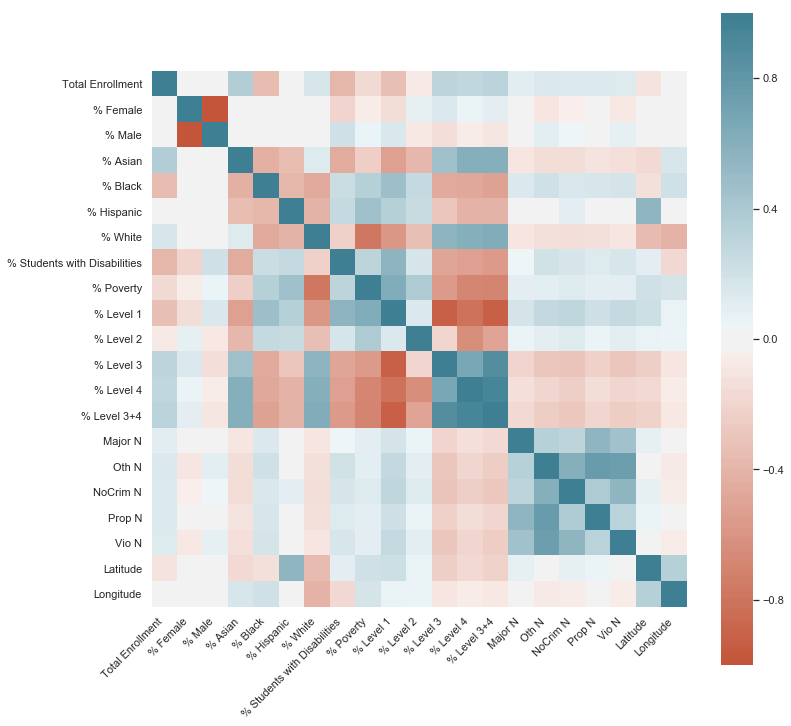

```python
plt.figure(figsize = (12, 12))
corr = school_MS.corr()
ax = sns.heatmap(corr, vmin = -1, vmax = 1, center = 0,
                 cmap = sns.diverging_palette(20, 220, n = 200),
                 square = True)
ax.set_xticklabels(
    ax.get_xticklabels(),
    rotation = 45,
    horizontalalignment = 'right');
```